# Estudio De Caso

Julian Velandia

2025-09-07

## Taller estudio de caso jugadores de futbol

# 1) Carga de datos

```r
library("dplyr")
library(ggplot2)
library(lmtest)
library(car)

baseDatos <- read.csv("D:/Documentos/RStudio Files/RCodesUnal/WORKSHOPS/EstudioDeCasoFutbol/players_15.csv")

baseDatos <- select(baseDatos, -release_clause_eur, -nation_jersey_number, -gk_kicking,
                    -gk_positioning, -gk_diving, -gk_reflexes, -gk_handling, -gk_speed,
                    -mentality_composure)

baseDatos <- baseDatos[!is.na(baseDatos$shooting), ]
```

Se cargaron los datos de la base de datos. Además de esto se eliminaron las columnas que tenian todos o la mayoria de datos como NA. Por otro lado, se revisaron las variables shooting, dribbling, pace, passing, defending y se encontró que los porteros no tenían información en estos campos. Se procedió a eliminar a los porteros del análisis estadistico.

Las variables ‘club’, ‘preferred_foot’, ‘team_position’, ‘age’, ‘height_cm’, ‘weight_kg’, ‘overall’,‘potential’,‘value_eur’,‘wage_eur’,‘shooting’,‘passing’, ‘dribbling’, ‘defending’, ‘physic’,‘pace’ son campos que representan información valiosa acerca de los jugadores a analizar. Por ejemplo, club, preferred_foot y team_position son datos character y el resto de estas variables son numeric.

# 2) Exploración de variables shooting y dribbling

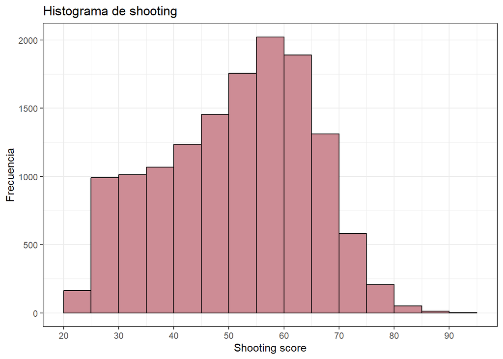

```r
## Analisis Variable Shooting
ggplot(baseDatos, aes(x = shooting)) +
  geom_histogram(binwidth = 5, boundary = 0, fill = "#CD8C95", color = "black") +
  scale_x_continuous(
    name = "Shooting score",
    breaks = seq(0, ceiling(max(baseDatos$shooting) / 10) * 10, by = 10)
  ) +
  ylab("Frecuencia") +
  ggtitle("Histograma de shooting") +
  theme_bw()
```

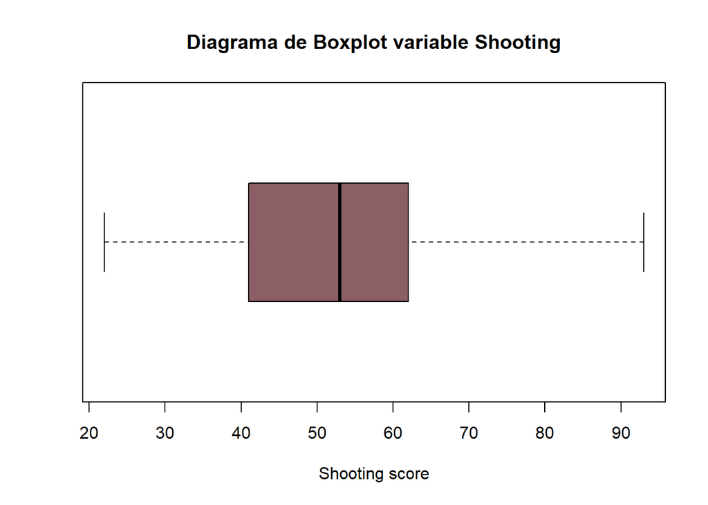

```r
boxplot(baseDatos$shooting, horizontal = TRUE,
        xlab = "Shooting score", col = "#8B5F65",
        main = "Diagrama de Boxplot variable Shooting")
```

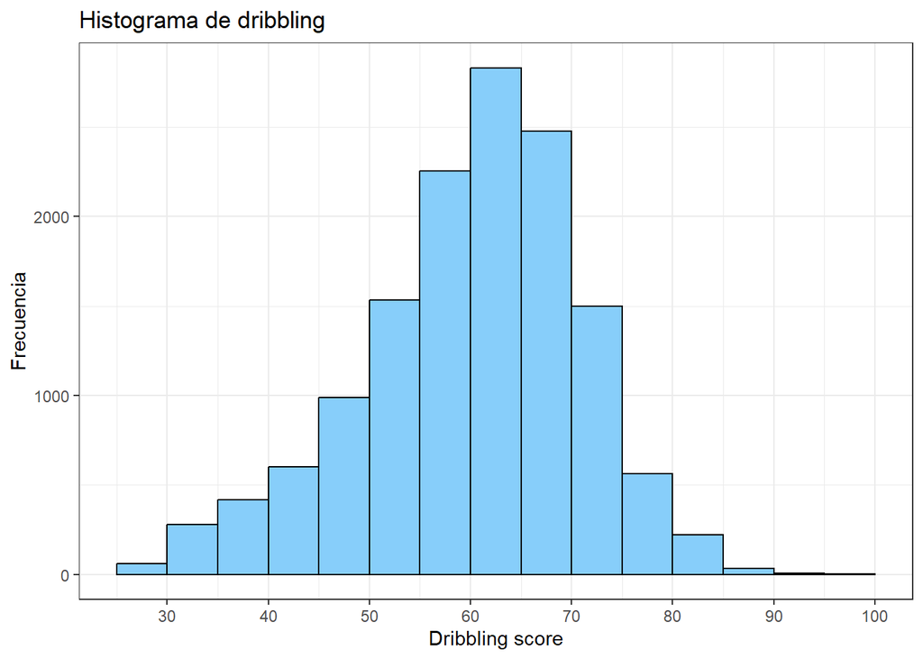

```r
## Analisis Variable Dribbling
ggplot(baseDatos, aes(x = dribbling)) +
  geom_histogram(binwidth = 5, boundary = 0, fill = "#87CEFA", color = "black") +
  scale_x_continuous(
    name = "Dribbling score",
    breaks = seq(0, ceiling(max(baseDatos$shooting) / 10) * 10, by = 10)
  ) +
  ylab("Frecuencia") +
  ggtitle("Histograma de dribbling") +
  theme_bw()
```

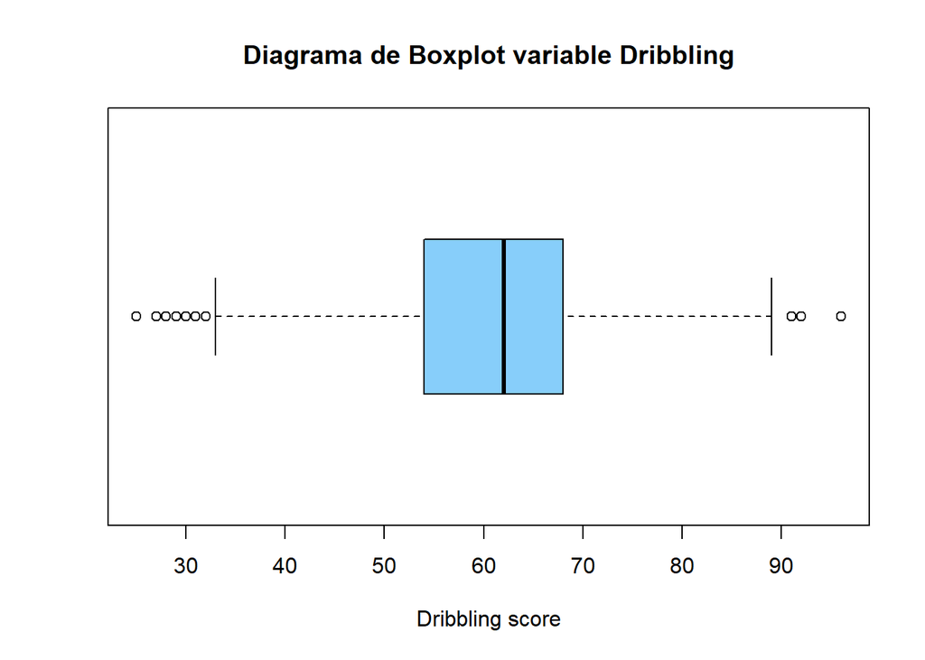

```r
boxplot(baseDatos$dribbling, horizontal = TRUE,
        xlab = "Dribbling score", col = "#87CEFA",
        main = "Diagrama de Boxplot variable Dribbling")
```

# 3) Regresión lineal simple

```r
# Muestra principal de 140 elementos
set.seed(10)
indices_muestra <- sample(nrow(baseDatos), 140)
muestra <- baseDatos[indices_muestra, ]

# Ahora sacamos los 10 datos solo de los que no fueron seleccionados antes
set.seed(7)
restantes <- setdiff(1:nrow(baseDatos), indices_muestra)
indices_test <- sample(restantes, 10)
test <- baseDatos[indices_test, ]
```

Se establece la muestra de 140 elementos con semilla 10. Además se crea otra muestra llamada test de 10 datos aleatorios con semilla 7 y que no esten incluidos dentro de la otra muestra.

Ahora, analizaremos la muestra tomada de 140 datos y se estudiará si pasa todas las pruebas para ser un modelo confiable, haciendo test de linealidad, correlacion, mocedasticidad y normalidad de los residuos o errores.

## a) Gráfico de disperción y Correlación

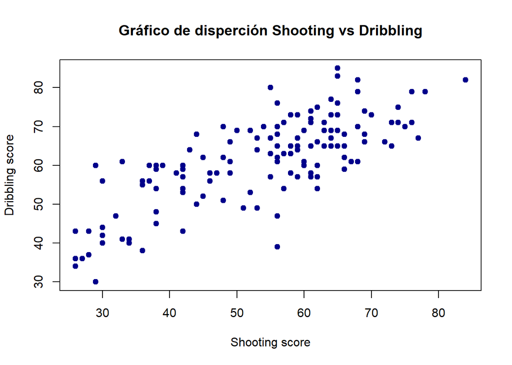

```r
# a)
plot(muestra$shooting, muestra$dribbling, col = "blue4",
     xlab = "Shooting score", ylab = "Dribbling score",
     main = "Gráfico de disperción Shooting vs Dribbling", pch = 19)
```

```r
cor(muestra$shooting, muestra$dribblin)
```

```
## [1] 0.7580853
```

## b) Coeficientes

```r
# b)
modelo <- lm(dribbling ~ shooting, muestra)
modelo$coefficients
```

```
## (Intercept)    shooting
##  28.0275225   0.6238631
```

En este caso es 28.0275225 es el intecepto con el eje y de la recta y 0.6238631 se refiere a la pendiente de la misma. Como se puede ver ninguno de los dos valores es 0.

## c) Prueba de hipotesis

```r
# c)
summary(modelo) # La hipotesis nula se rechaza, por lo tanto,
```

```
##
## Call:
## lm(formula = dribbling ~ shooting, data = muestra)
##
## Residuals:
##      Min       1Q   Median       3Q      Max
## -23.9639  -5.3698  -0.0326   5.0384  17.6600
##
## Coefficients:
##             Estimate Std. Error t value Pr(>|t|)
## (Intercept) 28.02752    2.51173   11.16   <2e-16 ***
## shooting     0.62386    0.04569   13.65   <2e-16 ***
## ---
## Signif. codes:  0 '***' 0.001 '**' 0.01 '*' 0.05 '.' 0.1 ' ' 1
##
## Residual standard error: 7.363 on 138 degrees of freedom
## Multiple R-squared:  0.5747, Adjusted R-squared:  0.5716
## F-statistic: 186.5 on 1 and 138 DF,  p-value: < 2.2e-16
```

Shooting está linealmente relacionado con dribbling y el coeficiente B1 es != 0.

## d) Prueba ANOVA

```r
# d)
anova(modelo)
```

```
## Analysis of Variance Table
##
## Response: dribbling
##            Df  Sum Sq Mean Sq F value    Pr(>F)
## shooting    1 10108.1 10108.1  186.47 < 2.2e-16 ***
## Residuals 138  7480.6    54.2
## ---
## Signif. codes:  0 '***' 0.001 '**' 0.01 '*' 0.05 '.' 0.1 ' ' 1
```

La hipotesis nula de que el modelo SIN shooting es tan bueno como el modelo CON shooting, se rechaza debido a p -value, por lo tanto, el modelo con shooting es significativamente mejor. Por otro lado, se puede evidenciar que el coeficiente de determinación es 0.5747.

## f) Analisis de residuos

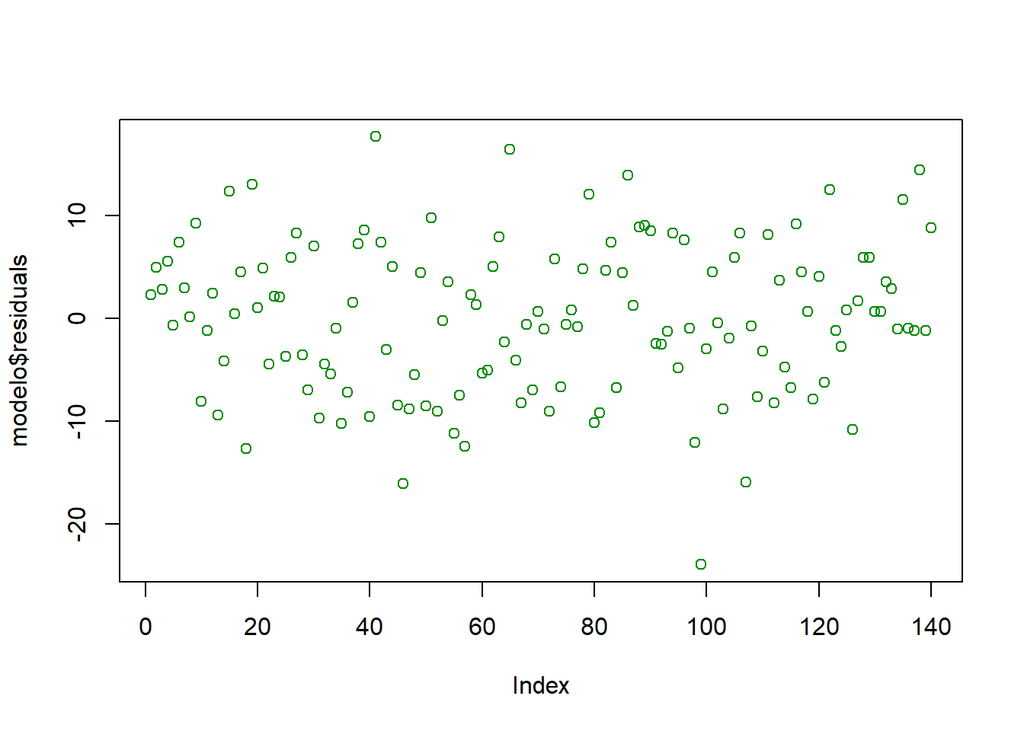

```r
# f)
plot(modelo$residuals, col = "green4")
```

```r
dwtest(modelo)
```

```
##
##  Durbin-Watson test
##
## data:  modelo
## DW = 2.0412, p-value = 0.6013
## alternative hypothesis: true autocorrelation is greater than 0
```

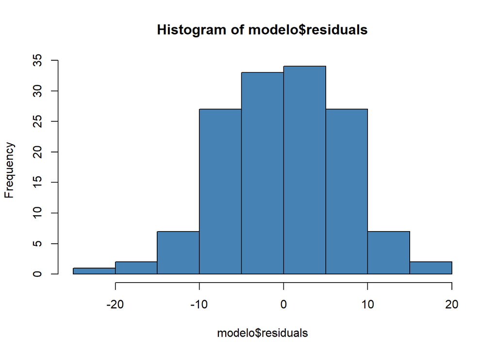

```r
hist(modelo$residuals, col = "steelblue")
```

```r
bptest(modelo)
```

```
##
##  studentized Breusch-Pagan test
##
## data:  modelo
## BP = 1.3907, df = 1, p-value = 0.2383
```

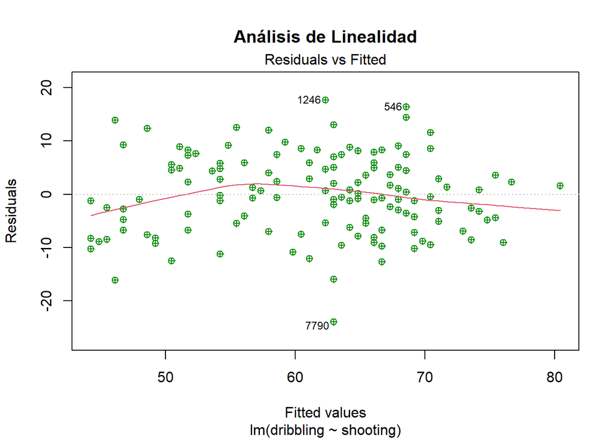

```r
plot(modelo, 1, main = "Análisis de Linealidad", col = "green4", pch = 10)
```

- Los residuos son independientes y no se encuentran correlacionados.
- Los residuos son normales como se representa en el histograma de residuos.
- Los residuos tienen varianza constante, es decir, existe homocedasticidad.
- Los residuos presentan linealidad ya que en el gráfico están distribuidos aleatoriamente.

# Valores atípicos o influyentes

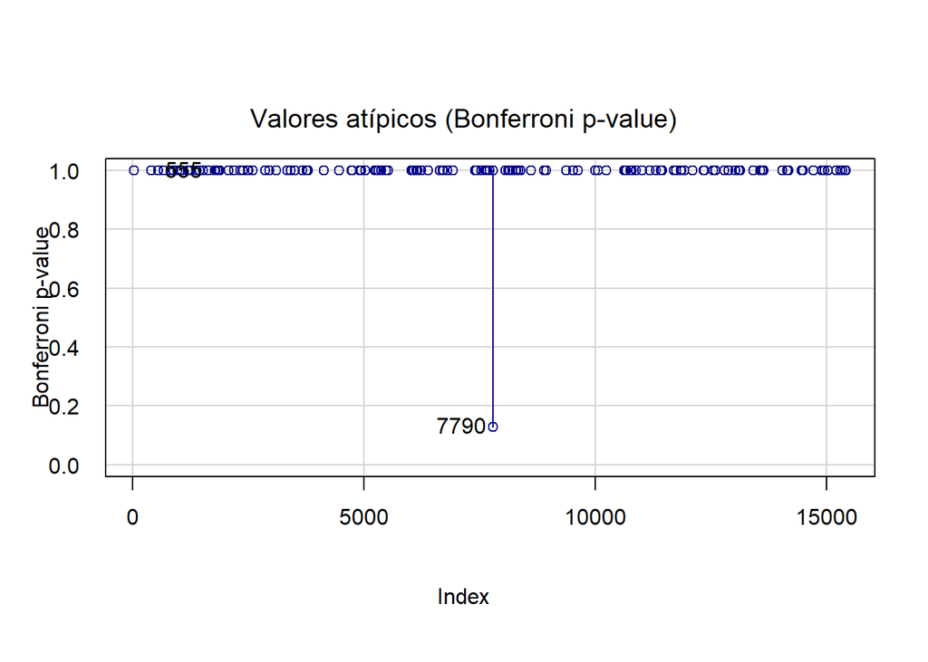

```r
# g)
par(mar = c(5, 5, 4, 2))
influenceIndexPlot(modelo, vars="Bonf", las=1, col = "darkblue",
                   main = "Valores atípicos (Bonferroni p-value)",
                   las = 1, ylim = c(0, 1))
```

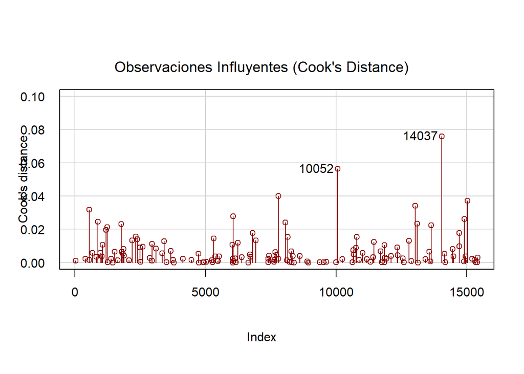

```r
par(mar = c(5, 6, 4, 2))
influenceIndexPlot(modelo, vars="Cook", col = "darkred",
                   main = "Observaciones Influyentes (Cook's Distance)",
                   las = 1, ylim = c(0, 0.1))
```

## h) Gráfica de intervalos de confianza

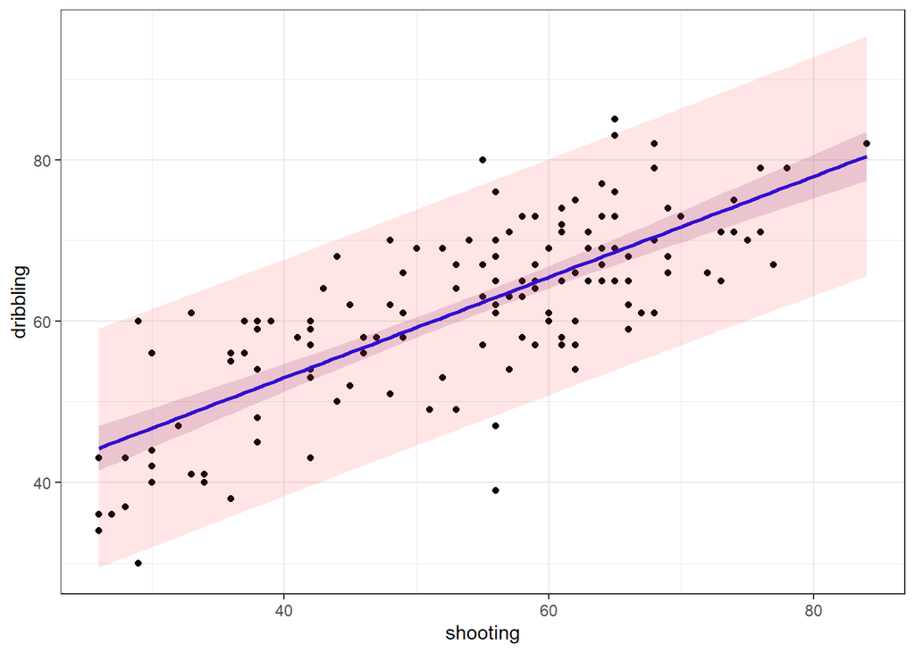

```r
# h)
nuevos_datos <- data.frame(shooting = seq(min(muestra$shooting),
                                          max(muestra$shooting), length.out = 100))
pred_conf <- predict(modelo, newdata = nuevos_datos, interval = "confidence", level = 0.95)
pred_pred <- predict(modelo, newdata = nuevos_datos, interval = "prediction", level = c(0.95))

nuevos_datos$fit <- pred_conf[, "fit"]
nuevos_datos$conf_lwr <- pred_conf[, "lwr"]
nuevos_datos$conf_upr <- pred_conf[, "upr"]
nuevos_datos$pred_lwr <- pred_pred[, "lwr"]
nuevos_datos$pred_upr <- pred_pred[, "upr"]

ggplot(muestra, aes(x=shooting, y=dribbling)) +
  geom_point() +
  geom_smooth(method = 'lm', formula = y~x, se=FALSE, col = 'blue') +
  geom_ribbon(data = nuevos_datos, aes(x = shooting, ymin = conf_lwr, ymax = conf_upr),
              fill = 'orchid4', alpha = 0.2, inherit.aes = FALSE) +
  geom_ribbon(data = nuevos_datos, aes(x = shooting, ymin = pred_lwr, ymax = pred_upr),
              fill = 'red', alpha = 0.1, inherit.aes = FALSE) +
  theme_bw()
```

## i) Base Test y datos de predicción

```r
#i)

predict(modelo, newdata = data.frame(shooting = 43), interval = "prediction", level = 0.95)
```

```
##        fit      lwr      upr
## 1 54.85363 40.21432 69.49295
```

```r
predict(modelo, newdata = data.frame(shooting = 27), interval = "prediction", level = 0.95)
```

```
##        fit      lwr      upr
## 1 44.87183 30.07051 59.67314
```

```r
predict(modelo, newdata = data.frame(shooting = 68), interval = "prediction", level = 0.95)
```

```
##        fit      lwr      upr
## 1 70.45021 55.77977 85.12065
```

```r
predict(modelo, newdata = data.frame(shooting = 53), interval = "prediction", level = 0.95)
```

```
##        fit      lwr      upr
## 1 61.09226 46.48232 75.70221
```

```r
predict(modelo, newdata = data.frame(shooting = 65), interval = "prediction", level = 0.95)
```

```
##        fit      lwr      upr
## 1 68.57862 53.93029 83.22696
```

```r
predict(modelo, newdata = data.frame(shooting = 43), interval = "prediction", level = 0.95)
```

```
##        fit      lwr      upr
## 1 54.85363 40.21432 69.49295
```

```r
predict(modelo, newdata = data.frame(shooting = 50), interval = "prediction", level = 0.95)
```

```
##        fit      lwr      upr
## 1 59.22068 44.60778 73.83357
```

```r
predict(modelo, newdata = data.frame(shooting = 50), interval = "prediction", level = 0.95)
```

```
##        fit      lwr      upr
## 1 59.22068 44.60778 73.83357
```

```r
predict(modelo, newdata = data.frame(shooting = 59), interval = "prediction", level = 0.95)
```

```
##        fit      lwr      upr
## 1 64.83544 50.21634 79.45455
```

```r
predict(modelo, newdata = data.frame(shooting = 48), interval = "prediction", level = 0.95)
```

```
##        fit      lwr      upr
## 1 57.97295 43.35529 72.59061
```

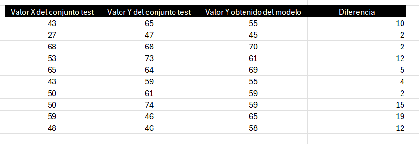